# MusicRecommenderSystem

```python
%cd D:\TrimesterIII\Innomatics\data\kaggle
```

```
D:\TrimesterIII\Innomatics\data\kaggle
```

## Introduction

### Recommendation Engines

Recommendation engines are a way of modeling and rearranging information available about user preferences and then using this information to provide informed recommendations on the basis of that information.

It is too important for online businesses, beyond to understanding and segment the customer, which have almost no physical interaction with their customers. Recommendation engines provide wonderful opportunities to these organizations to not only understand their clientele but also to use that information to increase their revenues. Another important advantage, you can easily integrate a crude recommendation engine in its interaction with the users and then, on the basis of its performance, make the decision to develop a more sophisticated version

### The Million Song Dataset

The dataset used in this nmotebook is available at https://drive.google.com/file/d/1iv0u71W3wXWS58-pnIPv6M6Mdsn39zUH/view?usp=sharing. The original dataset contained quantified audio features of around a million songs ranging over multiple years.

Although we will not be using this dataset directly, we will be using some parts of it. Several other datasets were spawned from the original million song dataset. One of those datasets was called The Echonest Taste Profile Subset. This particular dataset was created by The Echonest with some undisclosed partners. The dataset contains play counts by anonymous users for songs contained in the million songs dataset.

## Importing Necessary Packages

```python
import pandas as pd
import numpy as np
from pandas.plotting import scatter_matrix
from mpl_toolkits import mplot3d
import seaborn as sns
import Recommenders as Recommenders

%matplotlib inline

import os
import warnings
warnings.simplefilter(action = 'ignore', category=FutureWarning)
warnings.filterwarnings('ignore')
def ignore_warn(*args, **kwargs):
    pass

warnings.warn = ignore_warn #ignore annoying warning (from sklearn and seaborn)

import time
import matplotlib.pyplot as plt; plt.rcdefaults()
import matplotlib.pyplot as plt
from sklearn.model_selection import train_test_split
from scipy.sparse import coo_matrix
import math as mt
from scipy.sparse.linalg import * #used for matrix multiplication
from scipy.sparse.linalg import svds
from scipy.sparse import csc_matrix
from scipy.stats import skew, norm, probplot
import seaborn as sns
sns.set(style="ticks", color_codes=True, font_scale=1.5)
color = sns.color_palette()
sns.set_style('darkgrid')
```

## Loading Datasets

### Prepare Dataset

Most of recommendation engine use some kind of sparse matrix. So, we need load all data and merged them together so we can work with songs names instead of ID's. In a real production job, you'd stick with ID's and worry about the names at the display layer to make things more efficient. But this lets us understand what's going on better and you can use your understand to make recommendations not only for songs, but for band/artist and album/releases. Load Dataset

Since we have two datasets that can be joined by the song Id, first we need load then and make a check of consistent. We expect that track metadata has only one record per song, but we know that it is a common problem.

```python
songs_data = pd.read_csv("kaggle_songs.txt", header =0, names = ["song_id", "song_no"], sep = " ")
songs_data
```

|  | song_id | song_no |
| --- | --- | --- |
| 0 | SOAAADE12A6D4F80CC | 2 |
| 1 | SOAAADF12A8C13DF62 | 3 |
| 2 | SOAAADZ12A8C1334FB | 4 |
| 3 | SOAAAFI12A6D4F9C66 | 5 |
| 4 | SOAAAGK12AB0189572 | 6 |
| ... | ... | ... |
| 386207 | SOZZZRJ12AB0187A75 | 386209 |
| 386208 | SOZZZRV12A8C1361F1 | 386210 |
| 386209 | SOZZZSR12AB01854CD | 386211 |
| 386210 | SOZZZWD12A6D4F6624 | 386212 |
| 386211 | SOZZZWN12AF72A1E29 | 386213 |

386212 rows × 2 columns

```python
user_data = pd.read_csv("kaggle_users.txt", names = ["user_id"])
user_data
```

|  | user_id |
| --- | --- |
| 0 | fd50c4007b68a3737fe052d5a4f78ce8aa117f3d |
| 1 | d7083f5e1d50c264277d624340edaaf3dc16095b |
| 2 | d68dc6fc25248234590d7668a11e3335534ae4b4 |
| 3 | 9be82340a8b5ef32357fe5af957ccd54736ece95 |
| 4 | 841b2394ae3a9febbd6b06497b4a8ee8eb24b7f8 |
| ... | ... |
| 109995 | 07f2f354a2a4390624e0d04e4a555ef67e98f673 |
| 109996 | fe752b1aa2a12dbc203c37b70881d88481c655f1 |
| 109997 | ab79461415bb9db956def3a897886d0754ddddfb |
| 109998 | fc072bde2043756ea30ff07e4a5311e34825b4df |
| 109999 | 5e650759ebf89012044c6d52121eeada8b0ec814 |

110000 rows × 1 columns

```python
eval_data = pd.read_csv("kaggle_visible_evaluation_triplets.txt", sep ="\t", names = ["user_id","song_id", "freq"])
eval_data
```

|  | user_id | song_id | freq |
| --- | --- | --- | --- |
| 0 | fd50c4007b68a3737fe052d5a4f78ce8aa117f3d | SOBONKR12A58A7A7E0 | 1 |
| 1 | fd50c4007b68a3737fe052d5a4f78ce8aa117f3d | SOEGIYH12A6D4FC0E3 | 1 |
| 2 | fd50c4007b68a3737fe052d5a4f78ce8aa117f3d | SOFLJQZ12A6D4FADA6 | 1 |
| 3 | fd50c4007b68a3737fe052d5a4f78ce8aa117f3d | SOHTKMO12AB01843B0 | 1 |
| 4 | fd50c4007b68a3737fe052d5a4f78ce8aa117f3d | SODQZCY12A6D4F9D11 | 1 |
| ... | ... | ... | ... |
| 1450928 | 5e650759ebf89012044c6d52121eeada8b0ec814 | SOVLNXV12A6D4F706E | 1 |
| 1450929 | 5e650759ebf89012044c6d52121eeada8b0ec814 | SOVDSJC12A58A7A271 | 2 |
| 1450930 | 5e650759ebf89012044c6d52121eeada8b0ec814 | SOBRHVR12A8C133F35 | 2 |
| 1450931 | 5e650759ebf89012044c6d52121eeada8b0ec814 | SOMGVYU12A8C1314FF | 2 |
| 1450932 | 5e650759ebf89012044c6d52121eeada8b0ec814 | SOTCMDJ12A6D4F8528 | 3 |

1450933 rows × 3 columns

```python
eval_data.duplicated(["song_id"]).sum()
```

```
1287727
```

```python
tracks_data = pd.read_csv("taste_profile_song_to_tracks.txt",header = 0, names = ["song_id", "track_id"], sep = "\t",error_bad_lines=False)
tracks_data
```

[output not shown]

|  | song_id | track_id |
| --- | --- | --- |
| 0 | SOAAADE12A6D4F80CC | TRSKKFK128F148B615 |
| 1 | SOAAADF12A8C13DF62 | TRCQMSP128F428A6F7 |
| 2 | SOAAADZ12A8C1334FB | TRMDNZY128F425A532 |
| 3 | SOAAAFI12A6D4F9C66 | TRZEXLQ128F1491D17 |
| 4 | SOAAAGK12AB0189572 | TRDZUFJ12903CE29FC |
| ... | ... | ... |
| 385538 | SOZZZRJ12AB0187A75 | TRTMMRY12903CDE19D |
| 385539 | SOZZZRV12A8C1361F1 | TRCEWAR128F425D1B6 |
| 385540 | SOZZZSR12AB01854CD | TRPUDMM128F9308E1C |
| 385541 | SOZZZWD12A6D4F6624 | TRJMEUS128F1458975 |
| 385542 | SOZZZWN12AF72A1E29 | TRLAYKX128F92E728C |

385543 rows × 2 columns

```python
unique_data = pd.read_csv("unique_tracks.txt", sep = "<SEP>", names = ["track_id", "song_id", "artist_name", "song_name"], engine='python')
unique_data
```

|  | track_id | song_id | artist_name | song_name |
| --- | --- | --- | --- | --- |
| 0 | TRMMMYQ128F932D901 | SOQMMHC12AB0180CB8 | Faster Pussy cat | Silent Night |
| 1 | TRMMMKD128F425225D | SOVFVAK12A8C1350D9 | Karkkiautomaatti | Tanssi vaan |
| 2 | TRMMMRX128F93187D9 | SOGTUKN12AB017F4F1 | Hudson Mohawke | No One Could Ever |
| 3 | TRMMMCH128F425532C | SOBNYVR12A8C13558C | Yerba Brava | Si Vos Querés |
| 4 | TRMMMWA128F426B589 | SOHSBXH12A8C13B0DF | Der Mystic | Tangle Of Aspens |
| ... | ... | ... | ... | ... |
| 999995 | TRYYYUS12903CD2DF0 | SOTXAME12AB018F136 | Kiko Navarro | O Samba Da Vida |
| 999996 | TRYYYJO128F426DA37 | SOXQYIQ12A8C137FBB | Kuldeep Manak | Jago Chhadeo |
| 999997 | TRYYYMG128F4260ECA | SOHODZI12A8C137BB3 | Gabriel Le Mar | Novemba |
| 999998 | TRYYYDJ128F9310A21 | SOLXGOR12A81C21EB7 | Elude | Faraday |
| 999999 | TRYYYVU12903CD01E3 | SOWXJXQ12AB0189F43 | Texta | Fernweh feat. Sektion Kuchikäschtli |

1000000 rows × 4 columns

## EDA and Preprocessing

```python
print("Songs data has",sum(songs_data.isna().sum()),"null values")
print("User data has",sum(user_data.isna().sum()),"null values")
print("Evaluation data has",sum(eval_data.isna().sum()),"null values")
print("Tracks data has",sum(tracks_data.isna().sum()),"null values")
print("Unique songs data has",sum(unique_data.isna().sum()),"null values")
```

```
Songs data has 0 null values
User data has 0 null values
Evaluation data has 0 null values
Tracks data has 2380 null values
Unique songs data has 15 null values
```

```python
merged_data = pd.merge(eval_data, unique_data.drop_duplicates(['song_id']), on='song_id', how='left')
merged_data.head()
```

|  | user_id | song_id | freq | track_id | artist_name | song_name |
| --- | --- | --- | --- | --- | --- | --- |
| 0 | fd50c4007b68a3737fe052d5a4f78ce8aa117f3d | SOBONKR12A58A7A7E0 | 1 | TRAEHHJ12903CF492F | Dwight Yoakam | You're The One |
| 1 | fd50c4007b68a3737fe052d5a4f78ce8aa117f3d | SOEGIYH12A6D4FC0E3 | 1 | TRLGMFJ128F4217DBE | Barry Tuckwell/Academy of St Martin-in-the-Fie... | Horn Concerto No. 4 in E flat K495: II. Romanc... |
| 2 | fd50c4007b68a3737fe052d5a4f78ce8aa117f3d | SOFLJQZ12A6D4FADA6 | 1 | TRTNDNE128F1486812 | Cartola | Tive Sim |
| 3 | fd50c4007b68a3737fe052d5a4f78ce8aa117f3d | SOHTKMO12AB01843B0 | 1 | TRASTUE128F930D488 | Lonnie Gordon | Catch You Baby (Steve Pitron & Max Sanna Radio... |
| 4 | fd50c4007b68a3737fe052d5a4f78ce8aa117f3d | SODQZCY12A6D4F9D11 | 1 | TRFPLWO128F1486B9E | Miguel Calo | El Cuatrero |

Merging data and saving into a new datframe.

```python
merged_data.shape
```

```
(1450933, 6)
```

Our dataset now has 14,50,933 records. For each column.

```python
merged_data.head()
```

|  | user_id | song_id | freq | track_id | artist_name | song_name |
| --- | --- | --- | --- | --- | --- | --- |
| 0 | fd50c4007b68a3737fe052d5a4f78ce8aa117f3d | SOBONKR12A58A7A7E0 | 1 | TRAEHHJ12903CF492F | Dwight Yoakam | You're The One |
| 1 | fd50c4007b68a3737fe052d5a4f78ce8aa117f3d | SOEGIYH12A6D4FC0E3 | 1 | TRLGMFJ128F4217DBE | Barry Tuckwell/Academy of St Martin-in-the-Fie... | Horn Concerto No. 4 in E flat K495: II. Romanc... |
| 2 | fd50c4007b68a3737fe052d5a4f78ce8aa117f3d | SOFLJQZ12A6D4FADA6 | 1 | TRTNDNE128F1486812 | Cartola | Tive Sim |
| 3 | fd50c4007b68a3737fe052d5a4f78ce8aa117f3d | SOHTKMO12AB01843B0 | 1 | TRASTUE128F930D488 | Lonnie Gordon | Catch You Baby (Steve Pitron & Max Sanna Radio... |
| 4 | fd50c4007b68a3737fe052d5a4f78ce8aa117f3d | SODQZCY12A6D4F9D11 | 1 | TRFPLWO128F1486B9E | Miguel Calo | El Cuatrero |

```python
merged_data = merged_data.drop("track_id", axis =1)
```

Here There was a need of dropping either track_id column or song_id column. So, I dropped track_id data.

```python
merged_data.head()
```

|  | user_id | song_id | freq | artist_name | song_name |
| --- | --- | --- | --- | --- | --- |
| 0 | fd50c4007b68a3737fe052d5a4f78ce8aa117f3d | SOBONKR12A58A7A7E0 | 1 | Dwight Yoakam | You're The One |
| 1 | fd50c4007b68a3737fe052d5a4f78ce8aa117f3d | SOEGIYH12A6D4FC0E3 | 1 | Barry Tuckwell/Academy of St Martin-in-the-Fie... | Horn Concerto No. 4 in E flat K495: II. Romanc... |
| 2 | fd50c4007b68a3737fe052d5a4f78ce8aa117f3d | SOFLJQZ12A6D4FADA6 | 1 | Cartola | Tive Sim |
| 3 | fd50c4007b68a3737fe052d5a4f78ce8aa117f3d | SOHTKMO12AB01843B0 | 1 | Lonnie Gordon | Catch You Baby (Steve Pitron & Max Sanna Radio... |
| 4 | fd50c4007b68a3737fe052d5a4f78ce8aa117f3d | SODQZCY12A6D4F9D11 | 1 | Miguel Calo | El Cuatrero |

```python
merged_data.isna().sum()
```

```
user_id        0
song_id        0
freq           0
artist_name    0
song_name      1
dtype: int64
```

```python
merged_data = merged_data.fillna("NA")
```

There existed 1 null value for song_name. And was later filled by "NA".

```python
print("Total data points in merged data", merged_data.shape[0])
print("Total no. of unique user id are", merged_data["user_id"].unique().shape[0])
print("Total no. of unique songs id are", merged_data["song_id"].unique().shape[0])
print("Total no. of unique artists are", merged_data["artist_name"].unique().shape[0])
print("Total no. of unique songs are", merged_data["song_name"].unique().shape[0])
```

```
Total data points in merged data 1450933
Total no. of unique user id are 110000
Total no. of unique songs id are 163206
Total no. of unique artists are 28361
Total no. of unique songs are 137623
```

```python
merged_data["artist_name"].value_counts()
```

```
Coldplay                               12279
Kings Of Leon                           8514
Florence + The Machine                  8213
Justin Bieber                           7669
Jack Johnson                            6784
                                       ...
Fafá de Belém                              1
Peg Leg Sam featuring Louisiana Red        1
Big Mello                                  1
Neo Cortex                                 1
Poison Control Center                      1
Name: artist_name, Length: 28361, dtype: int64
```

```python
from scipy.stats import skew
import numpy as np

# random values based on a normal distribution

print ("X : \n", merged_data)

print('\nSkewness for data : ', skew(merged_data))
```

[output not shown]

```
array([[<AxesSubplot:title={'center':'freq'}>]], dtype=object)
```

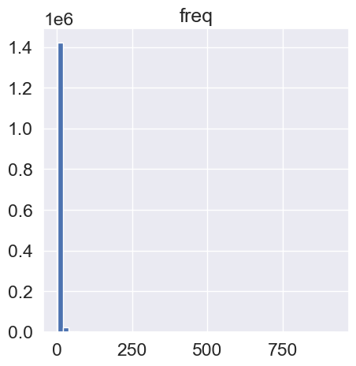

```python
merged_data.hist(bins=50, figsize=(5,5))
```

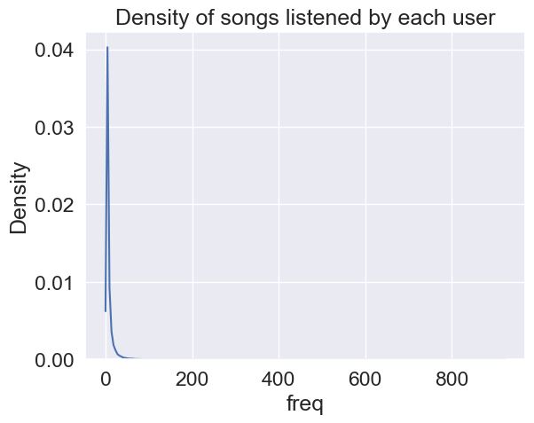

```python
sns.kdeplot(merged_data['freq'])
plt.plot()
plt.title("Density of songs listened by each user")
```

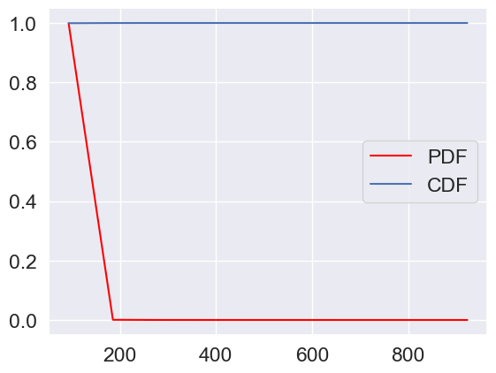

```python
count, bins = np.histogram(merged_data['freq'], bins=10)
pdf = count / sum(count)
cdf = np.cumsum(pdf)
plt.plot(bins[1:], pdf, color="red", label="PDF")
plt.plot(bins[1:], cdf, label="CDF")
plt.legend()
```

## Analysis on unique users

```python
songs_per_user = merged_data.groupby(['user_id']).song_id.nunique()
songs_per_user.head()
```

```
user_id
00007a02388c208ea7176479f6ae06f8224355b3     9
00014a76ed063e1a749171a253bca9d9a0ff1782    11
00015189668691680bb1a2e58afde1541ec92ced    17
0001ff7aa2667c8d8b945317b88adaed1c0b9dc2     9
00020fcd8b01986a6a85b896ccde6c49f35142ad    32
Name: song_id, dtype: int64
```

```python
songs_per_user.sort_values().head()
```

```
user_id
336c306c5df497a9cb4067c14d5b840ba1a1e272    5
47b83637c7726c40218552445e1dc9b906f0ad6d    5
5519a61514f2248435a70afad322568c1a1173eb    5
ae7a9eaf03f35908b8ffc420241f99e9c6057bf2    5
18cb5d68334667324a9bac0a66f6579f34f43a31    5
Name: song_id, dtype: int64
```

```python
songs_per_user.sort_values().tail()
```

```
user_id
0f8308935bcbb9a1e04ebb7c4d41c037e5f23b90    52
03ad93fdb01506ce205f4708decf8e4b1ae90fff    52
016a24e91a72c159a5048ab1b9b2ba5ce761b526    52
d30e18323f15426c3cdc8585252ed34459916f51    52
7d90be8dfdbde170f036ce8a4b915440137cb11c    53
Name: song_id, dtype: int64
```

```python
songs_per_user.describe()
```

```
count    110000.000000
mean         13.190300
std           8.070827
min           5.000000
25%           7.000000
50%          11.000000
75%          17.000000
max          53.000000
Name: song_id, dtype: float64
```

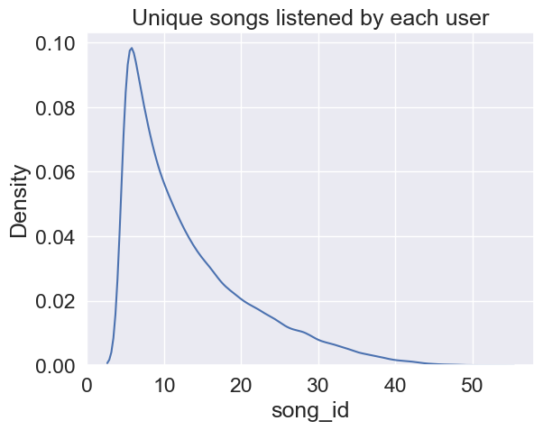

```python
sns.kdeplot(songs_per_user)
plt.plot()
plt.title("Unique songs listened by each user")
```

## Analysis on Popularity of an Artist

```python
artist_group = merged_data.groupby(['artist_name']).user_id.nunique()
artist_group.head()
```

```
artist_name
!!!                     91
!Deladap                 3
& And Oceans             2
'68 Comeback             5
'N Sync/Phil Collins    48
Name: user_id, dtype: int64
```

```python
artist_group.sort_values().head()
```

```
artist_name
Özlem Tekin                                                             1
Hurricane Chris featuring Mouse                                         1
Capone-N-Noreaga feat. Clipse_ Tha Dogg Pound_ Maino and Uncle Murda    1
Capone-N-Noreaga feat. Busta Rhymes and Ron Browz                       1
Hurricane Chris featuring Cherish                                       1
Name: user_id, dtype: int64
```

```python
artist_group.sort_values().tail()
```

```
artist_name
Harmonia                  5046
Train                     5182
Florence + The Machine    5596
Kings Of Leon             6858
Coldplay                  7036
Name: user_id, dtype: int64
```

```python
artist_songs = merged_data.groupby(['artist_name']).song_name.sum()
artist_songs
```

```
artist_name
!!!                     Must Be The MoonYadnusBend Over BeethovenMyth ...
!Deladap                Goldregen (N.O.H.A. Mix)Dela PajiGoldregen (N....
& And Oceans            Odious And DeviousAphelion: Light Evanescence:...
'68 Comeback            All Night LongSixteen TonsHalf-BreedTennessee ...
'N Sync/Phil Collins    Trashin' The Camp (Phil And 'N Sync Version)Tr...
                                              ...
Étienne Daho            Satori pop century (Live 1986)Epaule Tattoo (L...
Íon                     Fé_ Esperanza_ AmorO Efeito do VerãoUltreiaO E...
Ólafur Arnalds          Þú ert jörðin1953332630551440...og lengra0952Þ...
Órla Fallon                                             The Water Is Wide
Özlem Tekin                                                         A)sik
Name: song_name, Length: 28361, dtype: object
```

```python
np.unique(artist_songs['Coldplay'])
```

```
array(["YellowThe ScientistFix YouThe ScientistYellowFix YouThe ScientistFix YouYellowDon't PanicSparksYellowClocksThe ScientistFix YouLife In Technicolor iiFix YouSuch A RushFix You (Live)Speed Of SoundSpeed Of SoundThe ScientistFix YouLost!God Put A Smile Upon Your FaceBrothers & SistersA Rush Of …
      dtype='<U134062')
```

```python
np.unique(artist_songs['Justin Bieber'])
```

```
array(['Somebody To LoveDown To EarthOne TimeU SmileFavorite GirlLove MeCommon DenominatorNever Let You GoSomebody To LoveStuck In The MomentLove MeSomebody To LoveUpLove MeNever Let You GoOne Less Lonely GirlUpOne TimeThat Should Be MeNever Let You GoUpSomebody To LoveLove MeSomebody To LoveNever L…
      dtype='<U98791')
```

```python
sorted_artist_popularity = artist_group.sort_values(ascending=False)
```

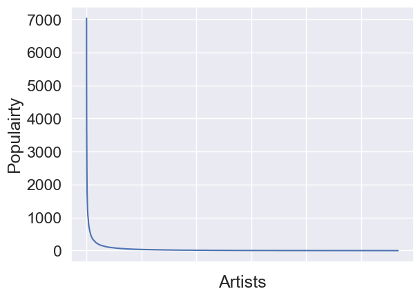

```python
plot1 = sorted_artist_popularity.plot()
plt.xlabel("Artists")
plt.ylabel("Populairty")
plot1.set(xticklabels=[])  # remove the tick labels
plot1.tick_params(bottom=False)  # remove the ticks
```

## Analysis on Song Popularity

```python
song_popularity = merged_data.groupby(['song_name']).user_id.nunique()
song_popularity
```

```
song_name

Ef Ég Hefði Aldrei...                                        1

Light Mass Prayers                                           4

The Arsonist Story":  Evil Craves Attention/Our Son/10x10    1

Ég Átti Gráa Æsku                                            4
 (Jack The Stripper)                                          2
                                                             ..
Þú ert jörðin                                                 2
Þú ert sólin                                                  2
ça Me Fait Du Bien                                            2
étienne d'août                                                4
þetta Gerist á Bestu Bæjum                                    1
Name: user_id, Length: 137623, dtype: int64
```

```python
song_popularity.sort_values().head()
```

```
song_name

Ef Ég Hefði Aldrei...              1
Making Love                         1
Making Friends and Acquaintances    1
Making Flippy Floppy                1
Making Dens                         1
Name: user_id, dtype: int64
```

```python
song_popularity.sort_values().tail()
```

```
song_name
Revelry                           3672
Dog Days Are Over (Radio Edit)    3780
You're The One                    4269
Undo                              4483
Sehr kosmisch                     5043
Name: user_id, dtype: int64
```

```python
sorted_song_popularity = song_popularity.sort_values(ascending=False)
```

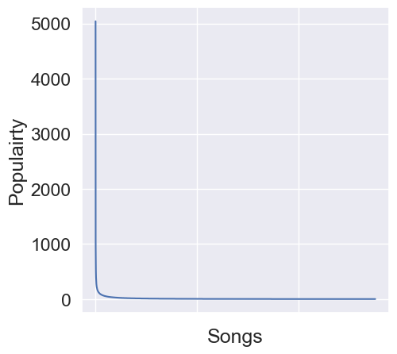

```python
plot2 = sorted_song_popularity.plot(figsize=(5, 5))
plot2.plot()
plt.xlabel("Songs")
plt.ylabel("Populairty")
plot2.set(xticklabels=[])  # remove the tick labels
plot2.tick_params(bottom=False)  # remove the ticks
```

```python
merged_data.describe().reset_index().T
```

|  | 0 | 1 | 2 | 3 | 4 | 5 | 6 | 7 |
| --- | --- | --- | --- | --- | --- | --- | --- | --- |
| index | count | mean | std | min | 25% | 50% | 75% | max |
| freq | 1450933.0 | 3.187149 | 7.051664 | 1.0 | 1.0 | 1.0 | 3.0 | 923.0 |

```python
play_count_data = merged_data[["user_id","song_id","freq"]]
```

```python
play_count_data
```

|  | user_id | song_id | freq |
| --- | --- | --- | --- |
| 0 | fd50c4007b68a3737fe052d5a4f78ce8aa117f3d | SOBONKR12A58A7A7E0 | 1 |
| 1 | fd50c4007b68a3737fe052d5a4f78ce8aa117f3d | SOEGIYH12A6D4FC0E3 | 1 |
| 2 | fd50c4007b68a3737fe052d5a4f78ce8aa117f3d | SOFLJQZ12A6D4FADA6 | 1 |
| 3 | fd50c4007b68a3737fe052d5a4f78ce8aa117f3d | SOHTKMO12AB01843B0 | 1 |
| 4 | fd50c4007b68a3737fe052d5a4f78ce8aa117f3d | SODQZCY12A6D4F9D11 | 1 |
| ... | ... | ... | ... |
| 1450928 | 5e650759ebf89012044c6d52121eeada8b0ec814 | SOVLNXV12A6D4F706E | 1 |
| 1450929 | 5e650759ebf89012044c6d52121eeada8b0ec814 | SOVDSJC12A58A7A271 | 2 |
| 1450930 | 5e650759ebf89012044c6d52121eeada8b0ec814 | SOBRHVR12A8C133F35 | 2 |
| 1450931 | 5e650759ebf89012044c6d52121eeada8b0ec814 | SOMGVYU12A8C1314FF | 2 |
| 1450932 | 5e650759ebf89012044c6d52121eeada8b0ec814 | SOTCMDJ12A6D4F8528 | 3 |

1450933 rows × 3 columns

```python
print('{:d} users, {:.2%} of total play counts, listening a single more than 200 times'.format(
    play_count_data.user_id[play_count_data.freq>200].unique().shape[0],
    play_count_data.freq[play_count_data.freq>200].count()/play_count_data.shape[0]))
display(play_count_data.freq[play_count_data.freq>200].describe().reset_index().T)
```

```
138 users, 0.01% of total play counts, listening a single more than 200 times
```

|  | 0 | 1 | 2 | 3 | 4 | 5 | 6 | 7 |
| --- | --- | --- | --- | --- | --- | --- | --- | --- |
| index | count | mean | std | min | 25% | 50% | 75% | max |
| freq | 154.0 | 286.188312 | 102.503038 | 201.0 | 221.0 | 250.0 | 310.25 | 923.0 |

```python
lunatic = play_count_data.freq[play_count_data.freq>play_count_data.freq.max()-10].values[0]
print('- How much days the most obsessed user can be the fan of a unique song: {:.1f}'.format((lunatic*3.5)/60/24))
display(merged_data[merged_data.song_id.isin(
                  play_count_data[play_count_data.freq>play_count_data.freq.max()-10].song_id.values)])
```

```
- How much days the most obsessed user can be the fan of a unique song: 2.2
```

|  | user_id | song_id | freq | artist_name | song_name |
| --- | --- | --- | --- | --- | --- |
| 1449167 | 22bb29714137fa47083963c30e1a26f1bf517e7d | SOXTUWG12AB018A2E2 | 923 | Kilgore | Drop The Hammer (Album Version) |

```python
obsessed = play_count_data.freq[play_count_data.freq>play_count_data.freq.max()-1500].values[1]
print('- How much days the second obsessed user can be the fan of a unique song: {:.1f}'.format((obsessed*3.5)/60/24))
display(merged_data[merged_data.song_id.isin(play_count_data[play_count_data.freq==923].song_id.values)])
```

```
- How much days the second obsessed user can be the fan of a unique song: 0.0
```

|  | user_id | song_id | freq | artist_name | song_name |
| --- | --- | --- | --- | --- | --- |
| 1449167 | 22bb29714137fa47083963c30e1a26f1bf517e7d | SOXTUWG12AB018A2E2 | 923 | Kilgore | Drop The Hammer (Album Version) |

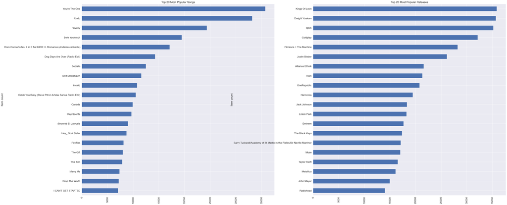

```python
fig = plt.figure(figsize=(50, 50))
a1 = fig.add_subplot(221)
popular_songs = merged_data[['song_name','freq']].groupby('song_name').sum().\
                sort_values('freq', ascending=False).head(20).sort_values('freq')
f1 = popular_songs.plot(kind='barh', title='Top 20 Most Popular Songs', legend=False, ax=a1)
plt.xticks(rotation='vertical')
plt.ylabel('Item count')

a2 = fig.add_subplot(222)
popular_release = merged_data[['artist_name','freq']].groupby('artist_name').sum().\
                sort_values('freq', ascending=False).head(20).sort_values('freq')
f2 = popular_release.plot(kind='barh', title='Top 20 Most Popular Releases', legend=False, ax=a2)
plt.xticks(rotation='vertical')
plt.ylabel('Item count')

plt.show()
```

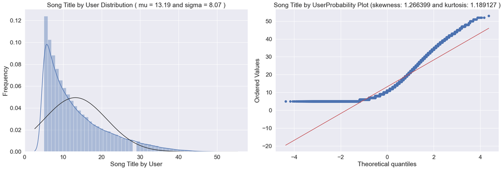

|  | 0 | 1 | 2 | 3 |
| --- | --- | --- | --- | --- |
| index | count | unique | top | freq |
| song_name | 1450933 | 137623 | Sehr kosmisch | 5043 |

```python
from scipy.stats import norm
user_song_count_distribution = merged_data[['user_id','song_name']].groupby('user_id').count().\
                                reset_index().sort_values(by='song_name',ascending = False)

def QQ_plot(data, measure):
    fig = plt.figure(figsize=(20,7))

    #Get the fitted parameters used by the function
    (mu, sigma) = norm.fit(data)

    #Kernel Density plot
    fig1 = fig.add_subplot(121)
    sns.distplot(data, fit=norm)
    fig1.set_title(measure + ' Distribution ( mu = {:.2f} and sigma = {:.2f} )'.format(mu, sigma), loc='center')
    fig1.set_xlabel(measure)
    fig1.set_ylabel('Frequency')

    #QQ plot
    fig2 = fig.add_subplot(122)
    res = probplot(data, plot=fig2)
    fig2.set_title(measure + 'Probability Plot (skewness: {:.6f} and kurtosis: {:.6f} )'.format(data.skew(), data.kurt()), loc='center')

    plt.tight_layout()
    plt.show()

QQ_plot(user_song_count_distribution.song_name, 'Song Title by User')
merged_data.song_name.describe().reset_index().T
```

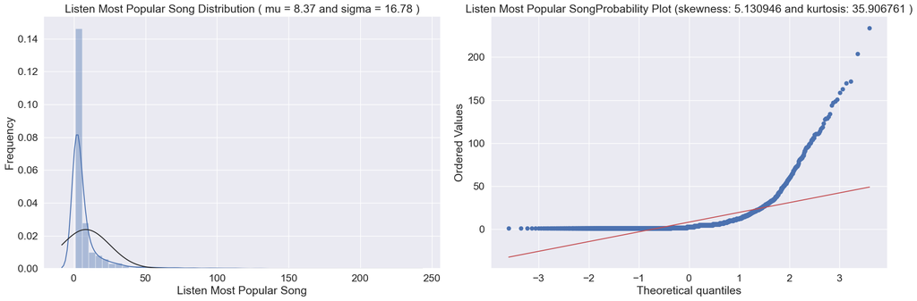

```python
QQ_plot(merged_data[merged_data.song_name=="You're The One"].freq, 'Listen Most Popular Song')
```

```python
song_grouped = merged_data.groupby(['song_name']).agg({'freq':'count'}).reset_index()
song_grouped.head()
```

|  | song_name | freq |
| --- | --- | --- |
| 0 | Ef Ég Hefði Aldrei... | 1 |
| 1 | Light Mass Prayers | 4 |
| 2 | The Arsonist Story": Evil Craves Attention/O... | 1 |
| 3 | Ég Átti Gráa Æsku | 4 |
| 4 | (Jack The Stripper) | 2 |

```python
grouped_sum = song_grouped['freq'].sum()
song_grouped['percentage'] = (song_grouped['freq'] / grouped_sum ) * 100
song_grouped.sort_values(['freq', 'song_name'], ascending=[0,1])
```

|  | song_name | freq | percentage |
| --- | --- | --- | --- |
| 98813 | Sehr kosmisch | 5043 | 0.347569 |
| 125394 | Undo | 4483 | 0.308974 |
| 136067 | You're The One | 4270 | 0.294293 |
| 28716 | Dog Days Are Over (Radio Edit) | 3780 | 0.260522 |
| 93985 | Revelry | 3672 | 0.253079 |
| ... | ... | ... | ... |
| 137609 | Último Desejo | 1 | 0.000069 |
| 137611 | Über Grenzen Geh'n | 1 | 0.000069 |
| 137613 | Übers Geld (Skit) | 1 | 0.000069 |
| 137615 | Üdvözöl A Pokol | 1 | 0.000069 |
| 137622 | þetta Gerist á Bestu Bæjum | 1 | 0.000069 |

137623 rows × 3 columns

# Recommendation Engine

```python
merged_data = merged_data.head(12000)
#Merge song title and artist_name columns to make a merged column
merged_data['song'] = merged_data['song_name'].map(str) + " - " + merged_data['artist_name']
```

```python
song_grouped = merged_data.groupby(['song']).agg({'freq': 'count'}).reset_index()
grouped_sum = song_grouped['freq'].sum()
song_grouped['percentage']  = song_grouped['freq'].div(grouped_sum)*100
song_grouped.sort_values(['freq', 'song'], ascending = [0,1])
```

|  | song | freq | percentage |
| --- | --- | --- | --- |
| 8567 | You're The One - Dwight Yoakam | 49 | 0.408333 |
| 6152 | Sehr kosmisch - Harmonia | 45 | 0.375000 |
| 7867 | Undo - Björk | 41 | 0.341667 |
| 5815 | Revelry - Kings Of Leon | 38 | 0.316667 |
| 1790 | Dog Days Are Over (Radio Edit) - Florence + Th... | 35 | 0.291667 |
| ... | ... | ... | ... |
| 8641 | Árboles de la barranca - Carlos Y Jose | 1 | 0.008333 |
| 8642 | Ännu En Dag - Drifters | 1 | 0.008333 |
| 8643 | Ça Marche - Christophe Maé | 1 | 0.008333 |
| 8644 | Örökké Tart - Tankcsapda | 1 | 0.008333 |
| 8645 | ça Me Fait Du Bien - Emmanuel Moire | 1 | 0.008333 |

8646 rows × 3 columns

```python
users = merged_data['user_id'].unique()
len(users)
```

```
906
```

```python
song = merged_data['song'].unique()
len(song)
```

```
8646
```

```python
train_data, test_data = train_test_split(merged_data, test_size = 0.20, random_state=0)
print(train_data.head(5))
```

```
                                       user_id             song_id  freq  \
843   e326c4b9fe3659ec1dc3af53fd7e0893809dafbc  SOGWJEY12AC9618862     1
9450  9d05fc6bf1116e17dff791309a6fdcb6d03c1dcf  SODIOKO12A6D4F79B6    14
7766  94e536831f1f786233a1cce36a865270811e686e  SOUVTSM12AC468F6A7     3
9802  f6c64e67ea4b4b8d50a40b0f418230f15d3a4c79  SOVEHLG12AF729B3C4     2
8555  6d853687403188430922f7065a509b4b392e7ae9  SOKMHKY12AF72AB079     1

             artist_name           song_name  \
843        Justin Bieber             Love Me
9450  Young Jeezy / Akon       Soul Survivor
7766  Lil Wayne / Eminem      Drop The World
9802       Thomas Newman  Mr. Ray_ Scientist
8555          Nickelback   How You Remind Me

                                     song
843               Love Me - Justin Bieber
9450   Soul Survivor - Young Jeezy / Akon
7766  Drop The World - Lil Wayne / Eminem
9802   Mr. Ray_ Scientist - Thomas Newman
8555       How You Remind Me - Nickelback
```

## Popularity Based Recommender Model

As the name suggests Popularity based recommendation system works with the trend. It basically uses the items which are in trend right now. For example, if any product which is usually bought by every new user then there are chances that it may suggest that item to the user who just signed up.

```python
#Class for Popularity based Recommender System model
class popularity_recommender_py():
    def __init__(self):
        self.train_data = None
        self.user_id = None
        self.item_id = None
        self.popularity_recommendations = None
    #Create the popularity based recommender system model
    def create(self, train_data, user_id, item_id):
        self.train_data = train_data
        self.user_id = user_id
        self.item_id = item_id
        #Get a count of user_ids for each unique song as recommendation score
        train_data_grouped = train_data.groupby([self.item_id]).agg({self.user_id: 'count'}).reset_index()
        train_data_grouped.rename(columns = {'user_id': 'score'},inplace=True)
        #Sort the songs based upon recommendation score
        train_data_sort = train_data_grouped.sort_values(['score', self.item_id], ascending = [0,1])
        #Generate a recommendation rank based upon score
        train_data_sort['Rank'] = train_data_sort['score'].rank(ascending=0, method='first')
        #Get the top 10 recommendations
        self.popularity_recommendations = train_data_sort.head(10)
    #Use the popularity based recommender system model to make recommendations
    def recommend(self, user_id):
        user_recommendations = self.popularity_recommendations
        #Add user_id column for which the recommendations are being generated
        user_recommendations['user_id'] = user_id
        #Bring user_id column to the front
        cols = user_recommendations.columns.tolist()
        cols = cols[-1:] + cols[:-1]
        user_recommendations = user_recommendations[cols]
        return user_recommendations
```

```python
# Create an instance of popularity based recommender class
pop_model = popularity_recommender_py()
pop_model.create(train_data, 'user_id', 'song')
```

```python
# Use the popularity model to make some predictions
user_id = users[10]
pop_model.recommend(user_id)
```

|  | user_id | song | score | Rank |
| --- | --- | --- | --- | --- |
| 7094 | fdf6afb5daefb42774617cf223475c6013969724 | You're The One - Dwight Yoakam | 41 | 1.0 |
| 5088 | fdf6afb5daefb42774617cf223475c6013969724 | Sehr kosmisch - Harmonia | 36 | 2.0 |
| 4803 | fdf6afb5daefb42774617cf223475c6013969724 | Revelry - Kings Of Leon | 32 | 3.0 |
| 6500 | fdf6afb5daefb42774617cf223475c6013969724 | Undo - Björk | 32 | 4.0 |
| 1467 | fdf6afb5daefb42774617cf223475c6013969724 | Dog Days Are Over (Radio Edit) - Florence + Th... | 29 | 5.0 |
| 649 | fdf6afb5daefb42774617cf223475c6013969724 | Billionaire [feat. Bruno Mars] (Explicit Albu... | 20 | 6.0 |
| 1940 | fdf6afb5daefb42774617cf223475c6013969724 | Fireflies - Charttraxx Karaoke | 20 | 7.0 |
| 1575 | fdf6afb5daefb42774617cf223475c6013969724 | Drop The World - Lil Wayne / Eminem | 19 | 8.0 |
| 3711 | fdf6afb5daefb42774617cf223475c6013969724 | Marry Me - Train | 19 | 9.0 |
| 186 | fdf6afb5daefb42774617cf223475c6013969724 | Ain't Misbehavin - Sam Cooke | 18 | 10.0 |

## Collaborative Filtering Recommender model

Also, the engine that we built is not really personal in that it doesn’t capture the personal tastes and biases of a user. Anyone querying our engine for recommendations based on a song will receive the same recommendations for that song, regardless of who she/he is.

Therefore, in this section, we will use a technique called Collaborative Filtering to make recommendations to Song listeners. It is basically of two types:-

```
-> User based filtering- These systems recommend products to a user that similar users have liked. For measuring the similarity between two users we can either use pearson correlation or cosine similarity.
Although computing user-based CF is very simple, it suffers from several problems. One main issue is that users’ preference can change over time. It indicates that precomputing the matrix based on their neighboring users may lead to bad performance. To tackle this problem, we can apply item-based CF.
-> Item Based Collaborative Filtering -Instead of measuring the similarity between users, the item-based CF recommends items based on their similarity with the items that the target user rated. Likewise, the similarity can be computed with Pearson Correlation or Cosine Similarity.
It successfully avoids the problem posed by dynamic user preference as item-based CF is more static. However, several problems remain for this method. First, the main issue is scalability. The computation grows with both the customer and the product. The worst case complexity is O(mn) with m users and n items. In addition, sparsity is another concern. In extreme cases, we can have millions of users and the similarity between two fairly different songs could be very high simply because they have similar rank for the only user who ranked them both.
```

We now create an item similarity based collaborative filtering model that allows us to make personalized recommendations to each user.

```python
merged_data.head()
```

|  | user_id | song_id | freq | artist_name | song_name | song |
| --- | --- | --- | --- | --- | --- | --- |
| 0 | fd50c4007b68a3737fe052d5a4f78ce8aa117f3d | SOBONKR12A58A7A7E0 | 1 | Dwight Yoakam | You're The One | You're The One - Dwight Yoakam |
| 1 | fd50c4007b68a3737fe052d5a4f78ce8aa117f3d | SOEGIYH12A6D4FC0E3 | 1 | Barry Tuckwell/Academy of St Martin-in-the-Fie... | Horn Concerto No. 4 in E flat K495: II. Romanc... | Horn Concerto No. 4 in E flat K495: II. Romanc... |
| 2 | fd50c4007b68a3737fe052d5a4f78ce8aa117f3d | SOFLJQZ12A6D4FADA6 | 1 | Cartola | Tive Sim | Tive Sim - Cartola |
| 3 | fd50c4007b68a3737fe052d5a4f78ce8aa117f3d | SOHTKMO12AB01843B0 | 1 | Lonnie Gordon | Catch You Baby (Steve Pitron & Max Sanna Radio... | Catch You Baby (Steve Pitron & Max Sanna Radio... |
| 4 | fd50c4007b68a3737fe052d5a4f78ce8aa117f3d | SODQZCY12A6D4F9D11 | 1 | Miguel Calo | El Cuatrero | El Cuatrero - Miguel Calo |

Class for an item similarity based personalized recommender system

```python
class item_similarity_recommender_py():
    def __init__(self):
        self.train_data = None
        self.user_id = None
        self.item_id = None
        self.cooccurence_matrix = None
        self.songs_dict = None
        self.rev_songs_dict = None
        self.item_similarity_recommendations = None
    #Get unique items (songs) corresponding to a given user
    def get_user_items(self, user):
        user_data = self.train_data[self.train_data[self.user_id] == user]
        user_items = list(user_data[self.item_id].unique())
        return user_items
    #Get unique users for a given item (song)
    def get_item_users(self, item):
        item_data = self.train_data[self.train_data[self.item_id] == item]
        item_users = set(item_data[self.user_id].unique())
        return item_users
    #Get unique items (songs) in the training data
    def get_all_items_train_data(self):
        all_items = list(self.train_data[self.item_id].unique())
        return all_items
    #Construct cooccurence matrix
    def construct_cooccurence_matrix(self, user_songs, all_songs):
        # Here we can Get users for all songs in user_songs.
        user_songs_users = []
        for i in range(0, len(user_songs)):
            user_songs_users.append(self.get_item_users(user_songs[i]))
        cooccurence_matrix = np.matrix(np.zeros(shape=(len(user_songs), len(all_songs))), float)
        #Calculate similarity between user songs and all unique songs
        #in the training data
        for i in range(0,len(all_songs)):
            #Calculate unique listeners (users) of song (item) i
            songs_i_data = self.train_data[self.train_data[self.item_id] == all_songs[i]]
            users_i = set(songs_i_data[self.user_id].unique())
            for j in range(0,len(user_songs)):
                #Get unique listeners (users) of song (item) j
                users_j = user_songs_users[j]
                #Calculate intersection of listeners of songs i and j
                users_intersection = users_i.intersection(users_j)
                #Calculate cooccurence_matrix[i,j] as Jaccard Index
                if len(users_intersection) != 0:
                    #Calculate union of listeners of songs i and j
                    users_union = users_i.union(users_j)
                    cooccurence_matrix[j,i] = float(len(users_intersection))/float(len(users_union))
                else:
                    cooccurence_matrix[j,i] = 0
        return cooccurence_matrix
    #Use the cooccurence matrix to make top recommendations
    def generate_top_recommendations(self, user, cooccurence_matrix, all_songs, user_songs):
        print("Non zero values in cooccurence_matrix :%d" % np.count_nonzero(cooccurence_matrix))

        #Calculate a weighted average of the scores in cooccurence matrix for all user songs.
        user_sim_scores = cooccurence_matrix.sum(axis=0)/float(cooccurence_matrix.shape[0])
        user_sim_scores = np.array(user_sim_scores)[0].tolist()

        #Sort the indices of user_sim_scores based upon their value
        #Also maintain the corresponding score
        sort_index = sorted(((e,i) for i,e in enumerate(list(user_sim_scores))), reverse=True)

        #Create a dataframe from the following
        columns = ['user_id', 'song', 'score', 'rank']
        #index = np.arange(1) # array of numbers for the number of samples
        df = pd.DataFrame(columns=columns)

        #Fill the dataframe with top 10 item based recommendations
        rank = 1
        for i in range(0,len(sort_index)):
            if ~np.isnan(sort_index[i][0]) and all_songs[sort_index[i][1]] not in user_songs and rank <= 10:
                df.loc[len(df)]=[user,all_songs[sort_index[i][1]],sort_index[i][0],rank]
                rank = rank+1

        #Handle the case where there are no recommendations
        if df.shape[0] == 0:
            print("The current user has no songs for training the item similarity based recommendation model.")
            return -1
        else:
            return df

    #Create the item similarity based recommender system model
    def create(self, train_data, user_id, item_id):
        self.train_data = train_data
        self.user_id = user_id
        self.item_id = item_id

    #Use the item similarity based recommender system model to make recommendations
    def recommend(self, user):
        # here we can Get all unique songs for this user
        user_songs = self.get_user_items(user)
        print("No. of unique songs for the user: %d" % len(user_songs))
        # Get all unique items (songs) in the training data
        all_songs = self.get_all_items_train_data()
        print("no. of unique songs in the training set: %d" % len(all_songs))
        # Construct item cooccurence matrix of size
        cooccurence_matrix = self.construct_cooccurence_matrix(user_songs, all_songs)
        # Use the cooccurence matrix to make recommendations
        df_recommendations = self.generate_top_recommendations(user, cooccurence_matrix, all_songs, user_songs)
        return df_recommendations

    #Get similar items to given items
    def get_similar_items(self, item_list):
        user_songs = item_list
        # Get all unique items (songs) in the training data
        all_songs = self.get_all_items_train_data()
        print("no. of unique songs in the training set: %d" % len(all_songs))
        #Construct item cooccurence matrix of size
        #len(user_songs) X len(songs)
        cooccurence_matrix = self.construct_cooccurence_matrix(user_songs, all_songs)
        #Use the cooccurence matrix to make recommendations
        user = ""
        df_recommendations = self.generate_top_recommendations(user, cooccurence_matrix, all_songs, user_songs)
        return df_recommendations
```

```python
# Create an instance of item similarity based recommender class
song_similar = item_similarity_recommender_py()
song_similar.create(train_data, 'user_id', 'song')
```

### Use the personalized model to make some song recommendations

```python
#Print the songs for the user in training data
user_id = users[20]
user_items = song_similar.get_user_items(user_id)
#
print("------------------------------------------------------------------------------------")
print("Training data songs for the user userid: %s:" % user_id)
print("------------------------------------------------------------------------------------")

for user_item in user_items:
    print(user_item)

print("----------------------------------------------------------------------")
print("Song will be Recommend soon:")
print("----------------------------------------------------------------------")

#Recommend songs for the user using personalized model
song_similar.recommend(user_id)
```

```
------------------------------------------------------------------------------------
Training data songs for the user userid: 4b9b549e84fb29bfbcf7ab34f01c0bcd1bbf93a5:
------------------------------------------------------------------------------------
It Just Don't Stop - Big Shug
Bleed It Out [Live At Milton Keynes] - Linkin Park
Stripped - Rammstein
Naked - Marques Houston
Education in Arkansas - Lewis Black
Hypnotized (featuring Akon) (Explicit Album Version) - Plies featuring Akon
Shine - Lil Wayne / Jazze Pha
Like Me (Amended Version) - Lil Scrappy
Unwell (Album Version) - matchbox twenty
Marry Me - Train
American Superstar [Feat. Lil Wayne] (Explicit Album Version) - Flo Rida
Undo - Björk
What It Is [feat. Rick Ross & Kollosus] (Explicit Album Version) - Gorilla Zoe
D & D - Stephen Lynch
Play - David Banner
I'm Me - Lil Wayne
Forget It - Breaking Benjamin
----------------------------------------------------------------------
Song will be Recommend soon:
----------------------------------------------------------------------
No. of unique songs for the user: 17
no. of unique songs in the training set: 7159
Non zero values in cooccurence_matrix :950
```

|  | user_id | song | score | rank |
| --- | --- | --- | --- | --- |
| 0 | 4b9b549e84fb29bfbcf7ab34f01c0bcd1bbf93a5 | Oh Very Young - Cat Stevens | 0.029412 | 1 |
| 1 | 4b9b549e84fb29bfbcf7ab34f01c0bcd1bbf93a5 | A Bad Penny - Cat Stevens | 0.029412 | 2 |
| 2 | 4b9b549e84fb29bfbcf7ab34f01c0bcd1bbf93a5 | Go Deep - Janet Jackson | 0.029412 | 3 |
| 3 | 4b9b549e84fb29bfbcf7ab34f01c0bcd1bbf93a5 | Something In The Way She Moves - James Taylor | 0.029412 | 4 |
| 4 | 4b9b549e84fb29bfbcf7ab34f01c0bcd1bbf93a5 | Where You Belong (With Bobo) - Blank + Jones | 0.029412 | 5 |
| 5 | 4b9b549e84fb29bfbcf7ab34f01c0bcd1bbf93a5 | Superstar - Usher | 0.029412 | 6 |
| 6 | 4b9b549e84fb29bfbcf7ab34f01c0bcd1bbf93a5 | What If? - Godsmack | 0.029412 | 7 |
| 7 | 4b9b549e84fb29bfbcf7ab34f01c0bcd1bbf93a5 | Boy - Nelly / Lil' Flip / Big Gipp | 0.029412 | 8 |
| 8 | 4b9b549e84fb29bfbcf7ab34f01c0bcd1bbf93a5 | Living In The U.S.A. (1991 Digital Remaster) -... | 0.029412 | 9 |
| 9 | 4b9b549e84fb29bfbcf7ab34f01c0bcd1bbf93a5 | Where I Wanna Be - Shade Sheist / Nate Dogg /... | 0.029412 | 10 |

```python
#We can also apply the model to find similar songs to any song in the dataset
song_similar.get_similar_items(['Principles Of Lust - Enigma'])
```

```
no. of unique songs in the training set: 7159
Non zero values in cooccurence_matrix :16
```

|  | user_id | song | score | rank |
| --- | --- | --- | --- | --- |
| 0 |  | It's A Pleasure - Sheree Brown | 1.0 | 1 |
| 1 |  | Spieluhr - Rammstein | 1.0 | 2 |
| 2 |  | Bossa Nova Cha Cha - Luiz Bonfa / Oscar Castro... | 1.0 | 3 |
| 3 |  | Shut Up - Black Eyed Peas | 1.0 | 4 |
| 4 |  | I Love You...I'Ll Kill You - Enigma | 1.0 | 5 |
| 5 |  | Ich Will - Rammstein | 1.0 | 6 |
| 6 |  | Mein Herz Brennt - Rammstein | 1.0 | 7 |
| 7 |  | A Thousand Years - Sting | 1.0 | 8 |
| 8 |  | Square Dance - Eminem | 1.0 | 9 |
| 9 |  | I Get Money - 50 Cent | 0.5 | 10 |

```python
songName = 'U Smile'
song_similar.get_similar_items([songName])
```

```
no. of unique songs in the training set: 7159
Non zero values in cooccurence_matrix :0
```

|  | user_id | song | score | rank |
| --- | --- | --- | --- | --- |
| 0 |  | Please Do Not Let Me Go - Ryan Adams | 0.0 | 1 |
| 1 |  | The Girl You Lost (Sander van Doorn Edit) - Sia | 0.0 | 2 |
| 2 |  | Ella Elle L A - Kate Ryan | 0.0 | 3 |
| 3 |  | I Only Think Of You - The Horrors | 0.0 | 4 |
| 4 |  | Time After Time - Everything But The Girl | 0.0 | 5 |
| 5 |  | Love - Sugarland | 0.0 | 6 |
| 6 |  | Flake - Jack Johnson | 0.0 | 7 |
| 7 |  | On Your Way - The Album Leaf | 0.0 | 8 |
| 8 |  | Nothing Is Promised feat. Yung Joc (Amended Al... | 0.0 | 9 |
| 9 |  | The Curse Of Curves (Album Version) - Cute Is ... | 0.0 | 10 |